# STAT 425 Assignment 5

**Due Tuesday, April 6, 11:59 pm.** Submit through Moodle.

## Name: (Kimmy Liu)

### Netid: (zl32)

Submit your computational work both as an R markdown (*.Rmd) document and as a pdf, along with any files needed to run the code. Embed your answers to each problem in the document below after the question statement. If you have hand-written work, please scan or take pictures of it and include in a pdf file, ideally combined with your pdf output file from R Markdown.

**Most relevant class notes:** 5.2.Spline, 6.Ancova, 7.VarSelect

## Problem 1

Consider the cancer surgery data from the library in . The variable is a measurement of prostate specific antigen on the log scale. Treat as the response and all the other variables in the data frame as potential predictors.

**a)** Using backward elimination testing and an alpha cutoff of 0.10, find the best model according to this procedure. Be sure to include the steps and the final model.

**Answer:**

```r
library(faraway)
model.1a = lm(lpsa~., data = prostate)
summary(model.1a)
```

```
##
## Call:
## lm(formula = lpsa ~ ., data = prostate)
##
## Residuals:
##     Min      1Q  Median      3Q     Max
## -1.7331 -0.3713 -0.0170  0.4141  1.6381
##
## Coefficients:
##              Estimate Std. Error t value Pr(>|t|)
## (Intercept)  0.669337   1.296387   0.516  0.60693
## lcavol       0.587022   0.087920   6.677 2.11e-09 ***
## lweight      0.454467   0.170012   2.673  0.00896 **
## age         -0.019637   0.011173  -1.758  0.08229 .
## lbph         0.107054   0.058449   1.832  0.07040 .
## svi          0.766157   0.244309   3.136  0.00233 **
## lcp         -0.105474   0.091013  -1.159  0.24964
## gleason      0.045142   0.157465   0.287  0.77503
## pgg45        0.004525   0.004421   1.024  0.30886
## ---
## Signif. codes:  0 '***' 0.001 '**' 0.01 '*' 0.05 '.' 0.1 ' ' 1
##
## Residual standard error: 0.7084 on 88 degrees of freedom
## Multiple R-squared:  0.6548, Adjusted R-squared:  0.6234
## F-statistic: 20.86 on 8 and 88 DF,  p-value: < 2.2e-16
```

Remove gleason:

```r
model.1b = lm(lpsa~lcavol+lweight+age+lbph+svi+lcp+pgg45, data = prostate)
summary(model.1b)
```

```
##
## Call:
## lm(formula = lpsa ~ lcavol + lweight + age + lbph + svi + lcp +
##     pgg45, data = prostate)
##
## Residuals:
##      Min       1Q   Median       3Q      Max
## -1.73117 -0.38137 -0.01728  0.43364  1.63513
##
## Coefficients:
##              Estimate Std. Error t value Pr(>|t|)
## (Intercept)  0.953926   0.829439   1.150  0.25319
## lcavol       0.591615   0.086001   6.879 8.07e-10 ***
## lweight      0.448292   0.167771   2.672  0.00897 **
## age         -0.019336   0.011066  -1.747  0.08402 .
## lbph         0.107671   0.058108   1.853  0.06720 .
## svi          0.757734   0.241282   3.140  0.00229 **
## lcp         -0.104482   0.090478  -1.155  0.25127
## pgg45        0.005318   0.003433   1.549  0.12488
## ---
## Signif. codes:  0 '***' 0.001 '**' 0.01 '*' 0.05 '.' 0.1 ' ' 1
##
## Residual standard error: 0.7048 on 89 degrees of freedom
## Multiple R-squared:  0.6544, Adjusted R-squared:  0.6273
## F-statistic: 24.08 on 7 and 89 DF,  p-value: < 2.2e-16
```

```r
model.1c = lm(lpsa~lweight+age+lbph+svi+lcp+pgg45, data = prostate)
summary(model.1c)
```

```
##
## Call:
## lm(formula = lpsa ~ lweight + age + lbph + svi + lcp + pgg45,
##     data = prostate)
##
## Residuals:
##      Min       1Q   Median       3Q      Max
## -1.81340 -0.52082 -0.02468  0.53754  1.98992
##
## Coefficients:
##              Estimate Std. Error t value Pr(>|t|)
## (Intercept)  0.482750   1.017328   0.475  0.63627
## lweight      0.593514   0.204839   2.897  0.00472 **
## age         -0.007415   0.013451  -0.551  0.58282
## lbph         0.086312   0.071413   1.209  0.22997
## svi          0.983457   0.294194   3.343  0.00121 **
## lcp          0.182831   0.098779   1.851  0.06746 .
## pgg45        0.004614   0.004223   1.093  0.27741
## ---
## Signif. codes:  0 '***' 0.001 '**' 0.01 '*' 0.05 '.' 0.1 ' ' 1
##
## Residual standard error: 0.8674 on 90 degrees of freedom
## Multiple R-squared:  0.4707, Adjusted R-squared:  0.4354
## F-statistic: 13.34 on 6 and 90 DF,  p-value: 9.279e-11
```

remove age:

```r
model.1d = lm(lpsa~lweight+lbph+svi+lcp+pgg45, data = prostate)
summary(model.1d)
```

```
##
## Call:
## lm(formula = lpsa ~ lweight + lbph + svi + lcp + pgg45, data = prostate)
##
## Residuals:
##      Min       1Q   Median       3Q      Max
## -1.84374 -0.50637 -0.02929  0.50275  1.94436
##
## Coefficients:
##             Estimate Std. Error t value Pr(>|t|)
## (Intercept) 0.103336   0.746298   0.138  0.89018
## lweight     0.572529   0.200499   2.856  0.00532 **
## lbph        0.076804   0.069033   1.113  0.26882
## svi         0.974992   0.292667   3.331  0.00125 **
## lcp         0.187417   0.098051   1.911  0.05910 .
## pgg45       0.004044   0.004078   0.992  0.32399
## ---
## Signif. codes:  0 '***' 0.001 '**' 0.01 '*' 0.05 '.' 0.1 ' ' 1
##
## Residual standard error: 0.864 on 91 degrees of freedom
## Multiple R-squared:  0.4689, Adjusted R-squared:  0.4397
## F-statistic: 16.07 on 5 and 91 DF,  p-value: 2.505e-11
```

remove pgg45:

```r
model.1d = lm(lpsa~lweight+lbph+svi+lcp, data = prostate)
summary(model.1d)
```

```
##
## Call:
## lm(formula = lpsa ~ lweight + lbph + svi + lcp, data = prostate)
##
## Residuals:
##     Min      1Q  Median      3Q     Max
## -1.8697 -0.5083  0.0135  0.6257  1.9292
##
## Coefficients:
##             Estimate Std. Error t value Pr(>|t|)
## (Intercept)  0.26217    0.72884   0.360 0.719886
## lweight      0.55677    0.19985   2.786 0.006482 **
## lbph         0.08620    0.06837   1.261 0.210620
## svi          0.99770    0.29174   3.420 0.000936 ***
## lcp          0.23504    0.08548   2.750 0.007181 **
## ---
## Signif. codes:  0 '***' 0.001 '**' 0.01 '*' 0.05 '.' 0.1 ' ' 1
##
## Residual standard error: 0.864 on 92 degrees of freedom
## Multiple R-squared:  0.4632, Adjusted R-squared:  0.4398
## F-statistic: 19.84 on 4 and 92 DF,  p-value: 8.34e-12
```

remove lbph:

```r
model.1e = lm(lpsa~lweight+svi+lcp, data = prostate)
summary(model.1e)
```

```
##
## Call:
## lm(formula = lpsa ~ lweight + svi + lcp, data = prostate)
##
## Residuals:
##      Min       1Q   Median       3Q      Max
## -1.92251 -0.57741  0.01187  0.56957  1.76000
##
## Coefficients:
##             Estimate Std. Error t value Pr(>|t|)
## (Intercept)  -0.1279     0.6620  -0.193 0.847260
## lweight       0.6695     0.1793   3.734 0.000325 ***
## svi           0.9427     0.2894   3.258 0.001569 **
## lcp           0.2414     0.0856   2.820 0.005875 **
## ---
## Signif. codes:  0 '***' 0.001 '**' 0.01 '*' 0.05 '.' 0.1 ' ' 1
##
## Residual standard error: 0.8667 on 93 degrees of freedom
## Multiple R-squared:  0.4539, Adjusted R-squared:  0.4363
## F-statistic: 25.76 on 3 and 93 DF,  p-value: 3.214e-12
```

**b)** Use backward selection in a stepwise algorithm to find the best model according to the AIC criterion. Be sure to include the steps and the final model.

**Answer:**

```r
final.mod = step(model.1a, direction = "backward")
```

```
## Start:  AIC=-58.32
## lpsa ~ lcavol + lweight + age + lbph + svi + lcp + gleason +
##     pgg45
##
##           Df Sum of Sq    RSS     AIC
## - gleason  1    0.0412 44.204 -60.231
## - pgg45    1    0.5258 44.689 -59.174
## - lcp      1    0.6740 44.837 -58.853
## <none>                 44.163 -58.322
## - age      1    1.5503 45.713 -56.975
## - lbph     1    1.6835 45.847 -56.693
## - lweight  1    3.5861 47.749 -52.749
## - svi      1    4.9355 49.099 -50.046
## - lcavol   1   22.3721 66.535 -20.567
##
## Step:  AIC=-60.23
## lpsa ~ lcavol + lweight + age + lbph + svi + lcp + pgg45
##
##           Df Sum of Sq    RSS     AIC
## - lcp      1    0.6623 44.867 -60.789
## <none>                 44.204 -60.231
## - pgg45    1    1.1920 45.396 -59.650
## - age      1    1.5166 45.721 -58.959
## - lbph     1    1.7053 45.910 -58.560
## - lweight  1    3.5462 47.750 -54.746
## - svi      1    4.8984 49.103 -52.037
## - lcavol   1   23.5039 67.708 -20.872
##
## Step:  AIC=-60.79
## lpsa ~ lcavol + lweight + age + lbph + svi + pgg45
##
##           Df Sum of Sq    RSS     AIC
## - pgg45    1    0.6590 45.526 -61.374
## <none>                 44.867 -60.789
## - age      1    1.2649 46.131 -60.092
## - lbph     1    1.6465 46.513 -59.293
## - lweight  1    3.5647 48.431 -55.373
## - svi      1    4.2503 49.117 -54.009
## - lcavol   1   25.4189 70.285 -19.248
##
## Step:  AIC=-61.37
## lpsa ~ lcavol + lweight + age + lbph + svi
##
##           Df Sum of Sq    RSS     AIC
## <none>                 45.526 -61.374
## - age      1    0.9592 46.485 -61.352
## - lbph     1    1.8568 47.382 -59.497
## - lweight  1    3.2251 48.751 -56.735
## - svi      1    5.9517 51.477 -51.456
## - lcavol   1   28.7665 74.292 -15.871
```

```r
final.mod
```

```
##
## Call:
## lm(formula = lpsa ~ lcavol + lweight + age + lbph + svi, data = prostate)
##
## Coefficients:
## (Intercept)       lcavol      lweight          age         lbph          svi
##     0.95100      0.56561      0.42369     -0.01489      0.11184      0.72095
```

Therefore, the best model here is:lpsa ~ lcavol + lweight + age + lbph + svi

```r
aic.mod = lm(lpsa ~ lcavol + lweight + age + lbph + svi, data = prostate)
summary(aic.mod)
```

```
##
## Call:
## lm(formula = lpsa ~ lcavol + lweight + age + lbph + svi, data = prostate)
##
## Residuals:
##      Min       1Q   Median       3Q      Max
## -1.83505 -0.39396  0.00414  0.46336  1.57888
##
## Coefficients:
##             Estimate Std. Error t value Pr(>|t|)
## (Intercept)  0.95100    0.83175   1.143 0.255882
## lcavol       0.56561    0.07459   7.583 2.77e-11 ***
## lweight      0.42369    0.16687   2.539 0.012814 *
## age         -0.01489    0.01075  -1.385 0.169528
## lbph         0.11184    0.05805   1.927 0.057160 .
## svi          0.72095    0.20902   3.449 0.000854 ***
## ---
## Signif. codes:  0 '***' 0.001 '**' 0.01 '*' 0.05 '.' 0.1 ' ' 1
##
## Residual standard error: 0.7073 on 91 degrees of freedom
## Multiple R-squared:  0.6441, Adjusted R-squared:  0.6245
## F-statistic: 32.94 on 5 and 91 DF,  p-value: < 2.2e-16
```

**c)** Use stepwise selection with the “both” option to find the best model according to the BIC criterion. Include the steps and the final model.

**Answer:**

```r
n=dim(prostate)[1]
final.mod = step(model.1a, direction = "both", k = log(n))
```

```
## Start:  AIC=-35.15
## lpsa ~ lcavol + lweight + age + lbph + svi + lcp + gleason +
##     pgg45
##
##           Df Sum of Sq    RSS     AIC
## - gleason  1    0.0412 44.204 -39.634
## - pgg45    1    0.5258 44.689 -38.576
## - lcp      1    0.6740 44.837 -38.255
## - age      1    1.5503 45.713 -36.377
## - lbph     1    1.6835 45.847 -36.095
## <none>                 44.163 -35.149
## - lweight  1    3.5861 47.749 -32.151
## - svi      1    4.9355 49.099 -29.448
## - lcavol   1   22.3721 66.535   0.030
##
## Step:  AIC=-39.63
## lpsa ~ lcavol + lweight + age + lbph + svi + lcp + pgg45
##
##           Df Sum of Sq    RSS     AIC
## - lcp      1    0.6623 44.867 -42.766
## - pgg45    1    1.1920 45.396 -41.627
## - age      1    1.5166 45.721 -40.936
## - lbph     1    1.7053 45.910 -40.537
## <none>                 44.204 -39.634
## - lweight  1    3.5462 47.750 -36.723
## + gleason  1    0.0412 44.163 -35.149
## - svi      1    4.8984 49.103 -34.014
## - lcavol   1   23.5039 67.708  -2.849
##
## Step:  AIC=-42.77
## lpsa ~ lcavol + lweight + age + lbph + svi + pgg45
##
##           Df Sum of Sq    RSS     AIC
## - pgg45    1    0.6590 45.526 -45.926
## - age      1    1.2649 46.131 -44.644
## - lbph     1    1.6465 46.513 -43.844
## <none>                 44.867 -42.766
## - lweight  1    3.5647 48.431 -39.925
## + lcp      1    0.6623 44.204 -39.634
## - svi      1    4.2503 49.117 -38.561
```

[output cut: 29 more lines]

```
## - lcavol   1   27.8298 74.315  -7.542
##
## Step:  AIC=-50.38
## lpsa ~ lcavol + lweight + svi
##
##           Df Sum of Sq    RSS     AIC
## <none>                 47.785 -50.377
## + lbph     1    1.3001 46.485 -48.478
## + pgg45    1    0.5735 47.211 -46.974
## + age      1    0.4025 47.382 -46.623
## + gleason  1    0.3890 47.396 -46.596
## + lcp      1    0.0641 47.721 -45.933
## - svi      1    5.1814 52.966 -44.966
## - lweight  1    5.8924 53.677 -43.673
## - lcavol   1   28.0445 75.829 -10.160
```

```r
final.mod
```

```
##
## Call:
## lm(formula = lpsa ~ lcavol + lweight + svi, data = prostate)
##
## Coefficients:
## (Intercept)       lcavol      lweight          svi
##     -0.2681       0.5516       0.5085       0.6662
```

Therefore, the final model is lpsa ~ lcavol + lweight + svi:

```r
bic.mod = lm(lpsa ~ lcavol + lweight + svi, data = prostate)
summary(bic.mod)
```

```
##
## Call:
## lm(formula = lpsa ~ lcavol + lweight + svi, data = prostate)
##
## Residuals:
##      Min       1Q   Median       3Q      Max
## -1.72964 -0.45764  0.02812  0.46403  1.57013
##
## Coefficients:
##             Estimate Std. Error t value Pr(>|t|)
## (Intercept) -0.26809    0.54350  -0.493  0.62298
## lcavol       0.55164    0.07467   7.388  6.3e-11 ***
## lweight      0.50854    0.15017   3.386  0.00104 **
## svi          0.66616    0.20978   3.176  0.00203 **
## ---
## Signif. codes:  0 '***' 0.001 '**' 0.01 '*' 0.05 '.' 0.1 ' ' 1
##
## Residual standard error: 0.7168 on 93 degrees of freedom
## Multiple R-squared:  0.6264, Adjusted R-squared:  0.6144
## F-statistic: 51.99 on 3 and 93 DF,  p-value: < 2.2e-16
```

**d)** Use the leaps and bounds algorithm to determine the model with smallest residual sums of squares for each model size from 2 to the maximum possible based on the number of columns in the data frame. Display the results by showing “which” variables were selected for model sizes 2, 3, etc.

**Answer:**

```r
library(leaps)
b=regsubsets(lpsa~., data = prostate)
rs = summary(b)
rs$which
```

```
##   (Intercept) lcavol lweight   age  lbph   svi   lcp gleason pgg45
## 1        TRUE   TRUE   FALSE FALSE FALSE FALSE FALSE   FALSE FALSE
## 2        TRUE   TRUE    TRUE FALSE FALSE FALSE FALSE   FALSE FALSE
## 3        TRUE   TRUE    TRUE FALSE FALSE  TRUE FALSE   FALSE FALSE
## 4        TRUE   TRUE    TRUE FALSE  TRUE  TRUE FALSE   FALSE FALSE
## 5        TRUE   TRUE    TRUE  TRUE  TRUE  TRUE FALSE   FALSE FALSE
## 6        TRUE   TRUE    TRUE  TRUE  TRUE  TRUE FALSE   FALSE  TRUE
## 7        TRUE   TRUE    TRUE  TRUE  TRUE  TRUE  TRUE   FALSE  TRUE
## 8        TRUE   TRUE    TRUE  TRUE  TRUE  TRUE  TRUE    TRUE  TRUE
```

**e)** Using the results from d) and further calculations, graph BIC versus model size for the models selected in part d). Which model is the overall best model according to BIC?

**Answer:**

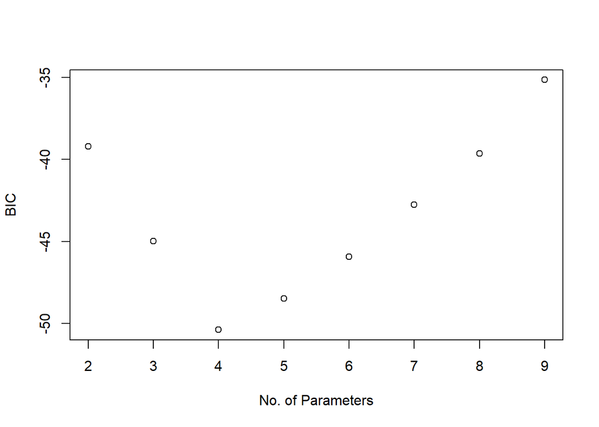

```r
msize = 2:9
Bic = n*log(rs$rss/n) + msize*log(n)
plot(msize, Bic, xlab="No. of Parameters", ylab = "BIC")
```

We can see that when the number of parameters is 4, BIC has the lowest value. Therefore, the overall best model according to BIC is:lpsa~lcavol+lwight+svi

```r
BIC.mod = lm(lpsa ~ lcavol + lweight + svi, data = prostate)
summary(BIC.mod)
```

```
##
## Call:
## lm(formula = lpsa ~ lcavol + lweight + svi, data = prostate)
##
## Residuals:
##      Min       1Q   Median       3Q      Max
## -1.72964 -0.45764  0.02812  0.46403  1.57013
##
## Coefficients:
##             Estimate Std. Error t value Pr(>|t|)
## (Intercept) -0.26809    0.54350  -0.493  0.62298
## lcavol       0.55164    0.07467   7.388  6.3e-11 ***
## lweight      0.50854    0.15017   3.386  0.00104 **
## svi          0.66616    0.20978   3.176  0.00203 **
## ---
## Signif. codes:  0 '***' 0.001 '**' 0.01 '*' 0.05 '.' 0.1 ' ' 1
##
## Residual standard error: 0.7168 on 93 degrees of freedom
## Multiple R-squared:  0.6264, Adjusted R-squared:  0.6144
## F-statistic: 51.99 on 3 and 93 DF,  p-value: < 2.2e-16
```

## Problem 2

The data in the library comes from the U.S. Historical Climatological Network. The data report annual mean temperatures in Ann Arbor Michigan for roughly 150 years.

**a)** With as the response, fit a regression spline with intercept using B-spline basis functions of and 8 degrees of freedom. Show the fitted curve on the scatter plot of versus .

**Answer:**

```r
library(ggplot2)
library(splines)
```

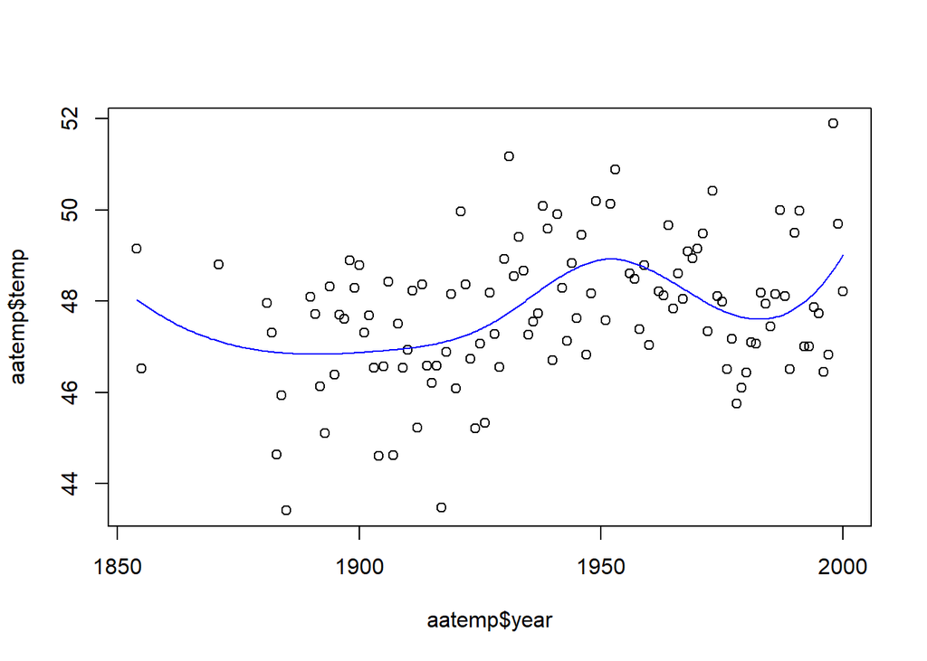

```r
model.sp = lm(temp~bs(year, df=8, intercept = TRUE), data=aatemp)
plot(aatemp$year, aatemp$temp);
lines(spline(aatemp$year, predict(model.sp)), col="blue")
```

**b)** How many knots does the model in a) have?

**Answer:** m = df-4 = 8-4 = 4

**c)** Compute AIC, BIC and adjusted R-square for the model in a).

**Answer:**

```r
AIC(model.sp)
```

```
## [1] 414.0364
```

```r
BIC(model.sp)
```

```
## [1] 438.7408
```

```r
summary(model.sp)$adj.r.squared
```

```
## [1] 0.1544943
```

**d)** Compute AIC for the b-spline models with degrees of freedom 4, 5, 6, … 20. Plot AIC versus degrees of freedom. Which of these models is the best, according to AIC?

**Answer:**

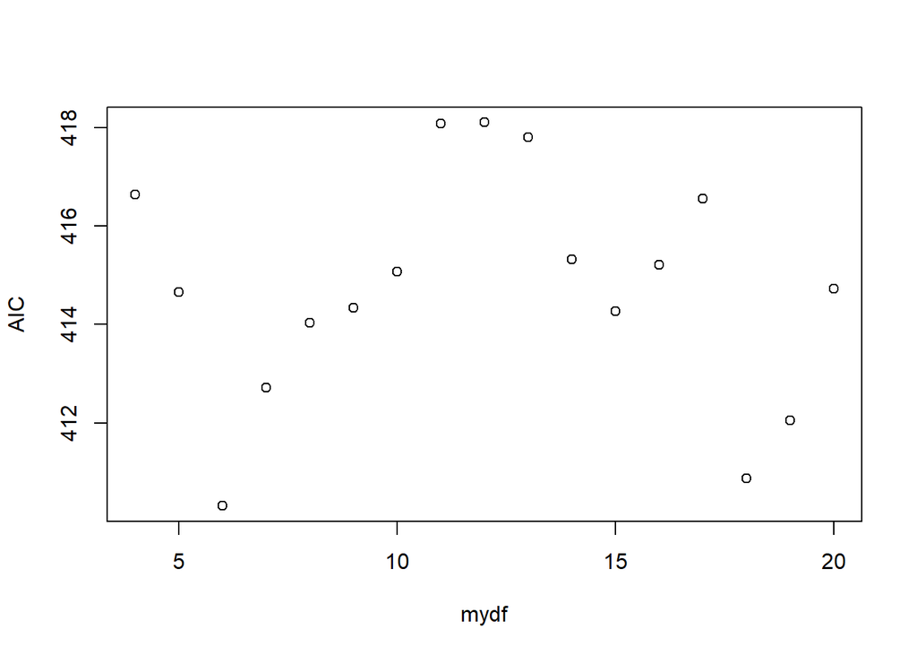

```r
mydf=4:20
AIC = rep(0, length(mydf))

for(i in 1:length(mydf)){
  mod = lm(temp~bs(year, df=mydf[i], intercept = TRUE), data=aatemp)
  AIC[i]=AIC(mod)
}
plot(mydf, AIC)
```

From the plot we can see that when the degree of freedom is 6, the AIC value is the lowest. Therefore, model with degree of freedom 6 is the best.

```r
BestMod = lm(temp~bs(year, df=6, intercept = TRUE), data=aatemp)
summary(BestMod)
```

```
##
## Call:
## lm(formula = temp ~ bs(year, df = 6, intercept = TRUE), data = aatemp)
##
## Residuals:
##     Min      1Q  Median      3Q     Max
## -3.6461 -0.9101 -0.2006  0.9427  3.3248
##
## Coefficients: (1 not defined because of singularities)
##                                     Estimate Std. Error t value Pr(>|t|)
## (Intercept)                          49.2156     0.6805  72.325  < 2e-16 ***
## bs(year, df = 6, intercept = TRUE)1  -1.2750     1.2123  -1.052  0.29525
## bs(year, df = 6, intercept = TRUE)2  -2.1648     1.1447  -1.891  0.06126 .
## bs(year, df = 6, intercept = TRUE)3  -3.4562     1.2532  -2.758  0.00682 **
## bs(year, df = 6, intercept = TRUE)4   1.2324     0.8554   1.441  0.15254
## bs(year, df = 6, intercept = TRUE)5  -3.1118     1.2573  -2.475  0.01486 *
## bs(year, df = 6, intercept = TRUE)6       NA         NA      NA       NA
## ---
## Signif. codes:  0 '***' 0.001 '**' 0.01 '*' 0.05 '.' 0.1 ' ' 1
##
## Residual standard error: 1.392 on 109 degrees of freedom
## Multiple R-squared:  0.2045, Adjusted R-squared:  0.168
## F-statistic: 5.604 on 5 and 109 DF,  p-value: 0.0001234
```

**e)** Show the fitted curve from the best model selected in d) on the scatter plot of versus . How does it compare with the curve in a)?

**Answer:**

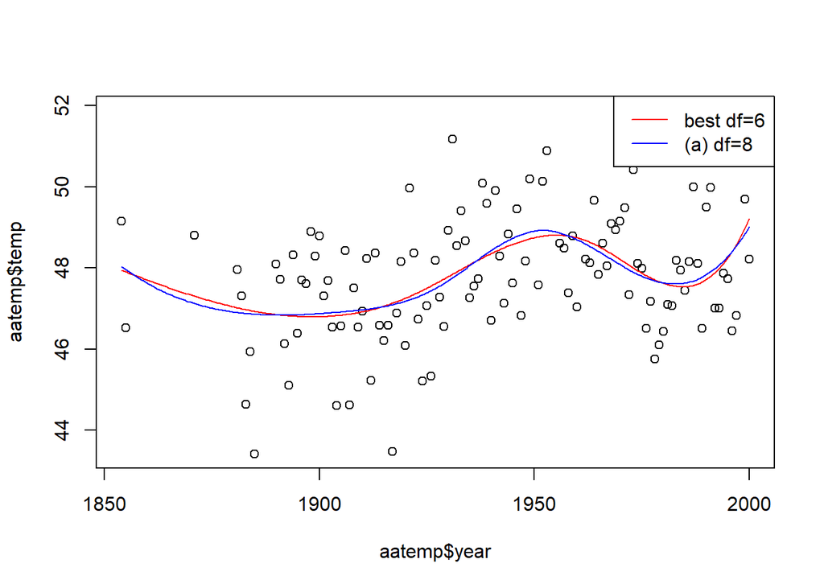

```r
Bestmod = lm(temp~bs(year, df=6, intercept = TRUE), data=aatemp)
plot(aatemp$year, aatemp$temp);
lines(spline(aatemp$year, predict(Bestmod)), col="red")
model.df8 = lm(temp~bs(year, df=8, intercept = TRUE), data=aatemp)
lines(spline(aatemp$year, predict(model.df8)), col="blue")
legend("topright", lty=c(1,1), col=c("red", "blue"), legend=c("best df=6", "(a) df=8"))
```

From the plot above we can see the red curve from the best mod and blue curve from (a), and it seems the red one is better fit.

## Problem 3:

In this problem we model data from a study of the prevalence of obesity, diabetes and cardiovascular disease among 403 African Americans in central Virginia. The data are in the dataset in the library. One of the blood measurements is glycosolated hemoglobin (). A value higher than 7 is often considered to be a positive diagnosis for diabetes. Here we treat the numerical value og as the response, and consider possible predictor variables (a factor variable), , , and stabilized glucose ().

**a)** Fit the ancova model that includes the main effects for , , , as well as the two-way interactions between gender and each of the other three predictor variables. Show the model summary and indicate which coefficients are significant at level 0.05.

**Answer:**

```r
mod.full = lm(glyhb~factor(gender)+waist+age+stab.glu+gender:waist+gender:age+gender:stab.glu, diabetes)
summary(mod.full)
```

```
##
## Call:
## lm(formula = glyhb ~ factor(gender) + waist + age + stab.glu +
##     gender:waist + gender:age + gender:stab.glu, data = diabetes)
##
## Residuals:
##     Min      1Q  Median      3Q     Max
## -8.2562 -0.7162 -0.1203  0.4528  9.6957
##
## Coefficients:
##                        Estimate Std. Error t value Pr(>|t|)
## (Intercept)            2.393920   0.838982   2.853  0.00456 **
## factor(gender)female  -2.492367   1.058500  -2.355  0.01905 *
## waist                 -0.011856   0.022109  -0.536  0.59210
## age                    0.013983   0.007507   1.863  0.06328 .
## stab.glu               0.027386   0.001891  14.484  < 2e-16 ***
## waist:genderfemale     0.048418   0.027563   1.757  0.07979 .
## age:genderfemale       0.003624   0.009664   0.375  0.70789
## stab.glu:genderfemale  0.005616   0.003001   1.872  0.06203 .
## ---
## Signif. codes:  0 '***' 0.001 '**' 0.01 '*' 0.05 '.' 0.1 ' ' 1
##
## Residual standard error: 1.45 on 380 degrees of freedom
##   (15 observations deleted due to missingness)
## Multiple R-squared:  0.5898, Adjusted R-squared:  0.5822
## F-statistic: 78.06 on 7 and 380 DF,  p-value: < 2.2e-16
```

From the plot we can see that gender and stab.glu are significant at level 0.05.

**b)** By comparing with a simplified model, test the null hypothesis that the three interaction coefficients all equal zero versus the alternative that at least one of them is nonzero. Use overall significance level of 0.05 and state your conclusion.

**Answer:**

```r
sim.mod = lm(glyhb~factor(gender)+waist+age+stab.glu, diabetes)
anova(sim.mod,mod.full)
```

|  | Res.Df | RSS | Df | Sum of Sq | F | Pr(>F) |
| --- | --- | --- | --- | --- | --- | --- |
| 1 | 383 | 818.9515 | NA | NA | NA | NA |
| 2 | 380 | 798.5198 | 3 | 20.43172 | 3.241019 | 0.02215569 |

Since the p-value of the F-test is smaller than 0.05, we reject the null hypothesis at the $\alpha=0.05$ level.We don’t accept the simplified model over the full model.

**c)** The additive model has only the main effects; no interactions are included. (Main effects are terms involving only the original variables, not their products). Fit this model and determine which of the main effects appear to have statistically significant coefficients at the 0.05 level.

**Answer:**

```r
additive.mod = lm(glyhb~factor(gender)+waist+age+stab.glu, diabetes)
summary(additive.mod)
```

```
##
## Call:
## lm(formula = glyhb ~ factor(gender) + waist + age + stab.glu,
##     data = diabetes)
##
## Residuals:
##     Min      1Q  Median      3Q     Max
## -8.7806 -0.7293 -0.1601  0.4072  9.6192
##
## Coefficients:
##                      Estimate Std. Error t value Pr(>|t|)
## (Intercept)          0.835159   0.520004   1.606 0.109084
## factor(gender)female 0.109011   0.151993   0.717 0.473683
## waist                0.020016   0.013315   1.503 0.133584
## age                  0.017042   0.004755   3.584 0.000382 ***
## stab.glu             0.029261   0.001474  19.851  < 2e-16 ***
## ---
## Signif. codes:  0 '***' 0.001 '**' 0.01 '*' 0.05 '.' 0.1 ' ' 1
##
## Residual standard error: 1.462 on 383 degrees of freedom
##   (15 observations deleted due to missingness)
## Multiple R-squared:  0.5793, Adjusted R-squared:  0.5749
## F-statistic: 131.9 on 4 and 383 DF,  p-value: < 2.2e-16
```

From the plot we can see that age and stab.glu appear to have statistically significant coefficients at the 0.05 level.

**d)** Compute AIC for the model in a) and the model in c). Which model is preferred according to this criterion?

**Answer:** AIC in (a)

```r
AIC(mod.full)
```

```
## [1] 1399.137
```

AIC in (c)

```r
AIC(additive.mod)
```

```
## [1] 1402.94
```

Since the AIC in (a) is smaller than AIC in (c), the (a) full mod with interactions between variables is preferred.

**e)** Use the sequential analysis of variance table for the full model in a) to determine which main effects and interactions are significant. What do you conclude?

**Answer:**

```r
anova(mod.full)
```

|  | Df | Sum Sq | Mean Sq | F value | Pr(>F) |
| --- | --- | --- | --- | --- | --- |
| factor(gender) | 1 | 4.806868 | 4.806868 | 2.2874949 | 1.312515e-01 |
| waist | 1 | 101.819320 | 101.819320 | 48.4538272 | 1.491652e-11 |
| age | 1 | 178.495274 | 178.495274 | 84.9424175 | 2.133021e-18 |
| stab.glu | 1 | 842.613593 | 842.613593 | 400.9833646 | 2.053024e-61 |
| waist:gender | 1 | 11.370195 | 11.370195 | 5.4108540 | 2.053729e-02 |
| age:gender | 1 | 1.700806 | 1.700806 | 0.8093802 | 3.688733e-01 |
| stab.glu:gender | 1 | 7.360720 | 7.360720 | 3.5028230 | 6.203238e-02 |
| Residuals | 380 | 798.519823 | 2.101368 | NA | NA |